# Response to 2020-07-16 e-mail

Abhijit Dasgupta, PhD

July 21, 2020 02:07 PM

**Data version:** The version of data we’re using is from 2020-01-31 15:45.

Could you provide us with a demographics breakdown so we can do a table 1 with

- Age at enrollment
- Gender
- Ethnicity
- Time since diagnosis

|  | Overall (N=677) |
| --- | --- |
| Age at enrollment (years) |  |
| Mean (SD) | 14.2 (3.09) |
| Median [Min, Max] | 15.0 [0, 20.0] |
| Sex |  |
| Female | 563 (83.2%) |
| Male | 114 (16.8%) |
| Race |  |
| White | 205 (30.3%) |
| Black | 178 (26.3%) |
| Asian | 80 (11.8%) |
| Mixed | 30 (4.4%) |
| Other race | 26 (3.8%) |
| Missing | 158 (23.3%) |
| Ethnicity |  |
| Hispanic | 172 (25.4%) |
| Non-hispanic | 505 (74.6%) |
| Time since diagnosis (years) |  |
| Mean (SD) | 1.07 (1.62) |
| Median [Min, Max] | 1.00 [0, 13.0] |

The total number of LN cases were reported as 234 and 235 different places throughout the data. Could you help clarify this?

From the raw biopsy data we have the following table:

LN Status

n

percent

FALSE

440

65.2%

TRUE

235

34.8%

Total

675

In the table for Principle 4 you are seeing 234 patients with LN. This is because for that analysis we were looking at number of visits after LN diagnosis. The information available for subject 597 showed that diagnosis was at an unscheduled visit, and where that visit was temporally between baseline, 6 month and 12 month visit was not available. So this subject was removed from that analysis since the number of visits post diagnosis could not be computed for that subject.

This has now been noted in the original report

For principle 2, the total of LN is 217 instead of 235. I think this wasn’t updated when we added in the rest of the nephritis patients (class I and II) to principle 1

This wasn’t quite the problem. I had truncated the table to 2 or fewer years, and so several individuals were omitted from this table. It has now been fixed in the original report (summaries.html, attached)

For principle 2, can we do a kaplan meyer curve for time to nephritis?

Yes, I can, though it will be a bit choppy due to the fact that we only have years since diagnosis, and not more granular data. Added to summaries.html

### UPC information

For principle 3, can you please report the UPC by class both the numerical and categorical variable? I know the data is limited but we’d like to report what we have

This analysis has been added to Principle 3 in summary.html

For principle 4, the GFR table total is 234 not 235 including NA. Where did the one patient go?

This has been answered above

For principle 5, what is the p-value for the change in GFR? Can we do this by collapsing state 2 and state 3 into one group and compare GFR >60 vs <60?

This is an ill-posed problem. What is the hypothesis test you’re asking for? If you’re testing H<sub>0</sub>: *No difference between Stage 1 and Stage 2+3 in what proportion get worse* vs H<sub>1</sub>: *Stage 2+3 gets worse more often than Stage 1*, which is how I interpret the principle, then you have a problem. People starting in Stage 2+3 cannot get worse.

You could consider if eGFR values worsen on average for non-Stage 1 patients compared to Stage 1 patients.

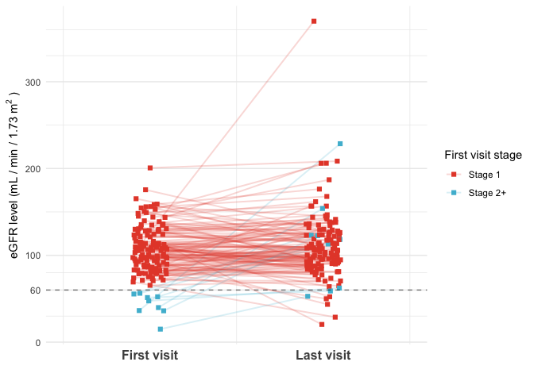

For principle 6, for the top medications- which patients are being compared? What is the denominator?

Thanks for bringing this up. It looks like I didn’t quite do the right thing before (hence your confusion). I’ve updated the tables in summary.html. Denominators for each entity is the number of Ritux users or non-Ritux subjects as the case might be for each column. This is what makes sense to me. So the interpretation of the *With Ritux* entries is the proportion of Ritux users who also took the drug in quesiton.